# Презентация по лабораторной работе №5

Дисциплина: Администрирование локальных сетей

Доберштейн А.C.

Российский университет дружбы народов, Москва, Россия

04 апреля 2025

# Информация

## Докладчик

- Доберштейн Алина Сергеевна
- 1132226448
- НФИбд-02-22

# Цель работы

Получить основные навыки по настройке VLAN на коммутаторах сети.

# Задание

1. На коммутаторах сети настроить Trunk-порты на соответствующих интерфейсах, связывающих коммутаторы между собой.
2. Коммутатор msk-donskaya-sw-1 настроить как VTP-сервер и прописать на нём номера и названия VLAN согласно табл. 3.1 из раздела 3.3.
3. Коммутаторы msk-donskaya-sw-2 — msk-donskaya-sw-4, mskpavlovskaya-sw-1 настроить как VTP-клиенты, на интерфейсах указать принадлежность к соответствующему VLAN.
4. На серверах прописать IP-адреса, как указано в табл. 3.2 из раздела 3.3.
5. На оконечных устройствах указать соответствующий адрес шлюза и прописать статические IP-адреса из диапазона соответствующей сети, следуя регламенту выделения ip-адресов.
6. Проверить доступность устройств, принадлежащих одному VLAN, и недоступность устройств, принадлежащих разным VLAN.
7. При выполнении работы необходимо учитывать соглашение об именовании.

# Выполнение лабораторной работы

Используя приведенную ниже последовательность команд, настроила trunk порты на соответствующих интерфейсах всех коммутаторов. (рис. @fig:001).

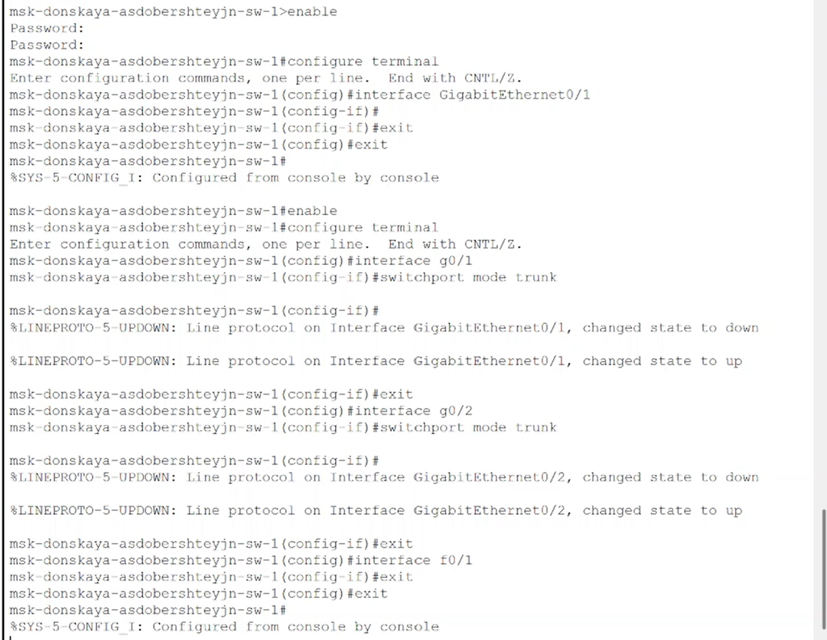

Настройка Trunk портов на коммутаторе msk-donskaya-asdobershteyjn-sw-1

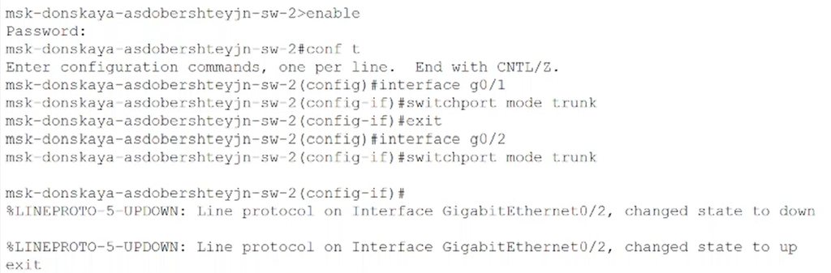

Настройка Trunk портов на коммутаторе msk-donskaya-asdobershteyjn-sw-2

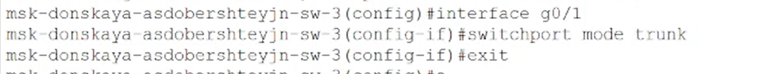

Настройка Trunk портов на коммутаторе msk-donskaya-asdobershteyjn-sw-3

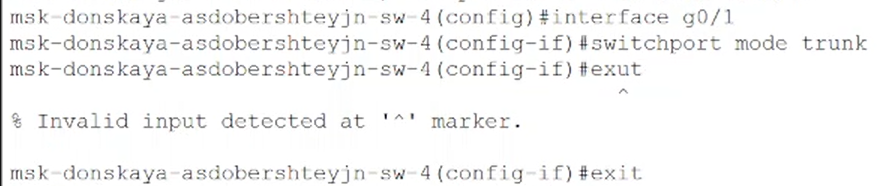

Настройка Trunk портов на коммутаторе msk-donskaya-asdobershteyjn-sw-4

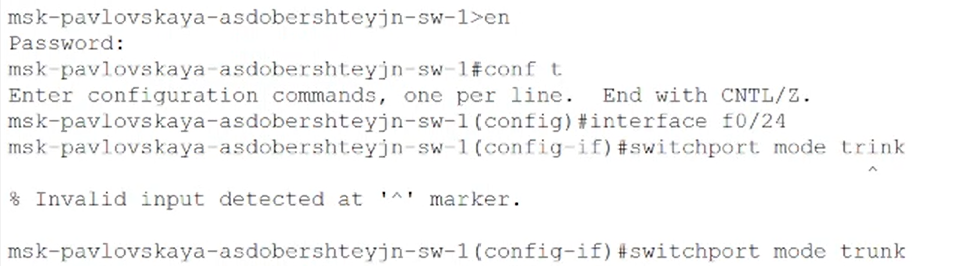

Настройка Trunk портов на коммутаторе msk-pavlovskaya-asdobershteyjn-sw-1

Используя приведенную ниже последовательность команд по конфигурации VTP, настроила коммутатор msk-donskaya-sw-1 как VTP-сервер и прописала на нем номера и названия VLAN. (рис. @fig:006).

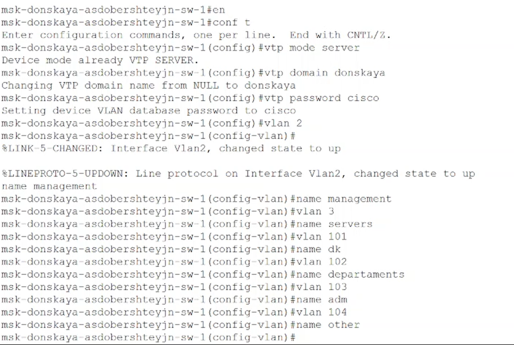

Настройка коммутатора msk-donskaya-asdobershteyjn-sw-1 как VTP-сервер

Используя приведенную ниже последовательность команд по конфигурации диапазонов портов, настроила коммутаторы msk-donskaya-sw-2 - msk-donskaya-sw-4, msk-pavlovskaya-sw-1 как VTP-клиенты и на интерфейсах указала принадлежность к VLAN.(рис. @fig:007).

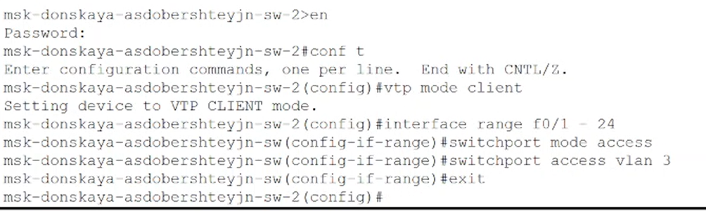

Настройка коммутатора msk-donskaya-asdobershteyjn-sw-2 как VTP-клиент

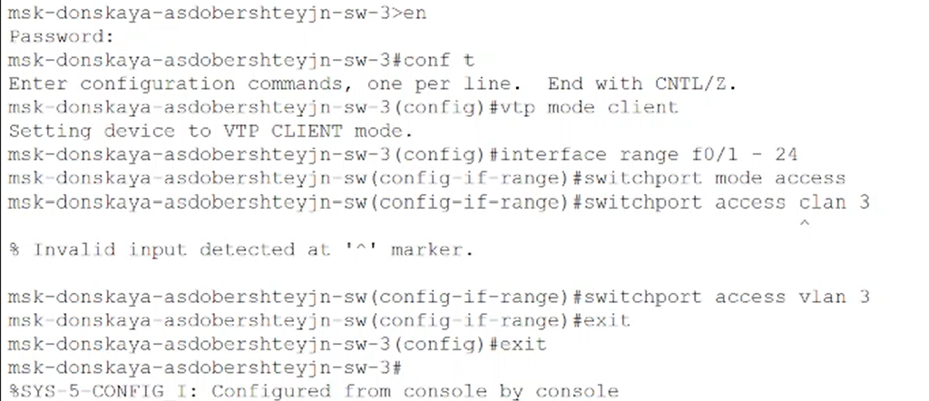

Настройка коммутатора msk-donskaya-asdobershteyjn-sw-3 как VTP-клиент

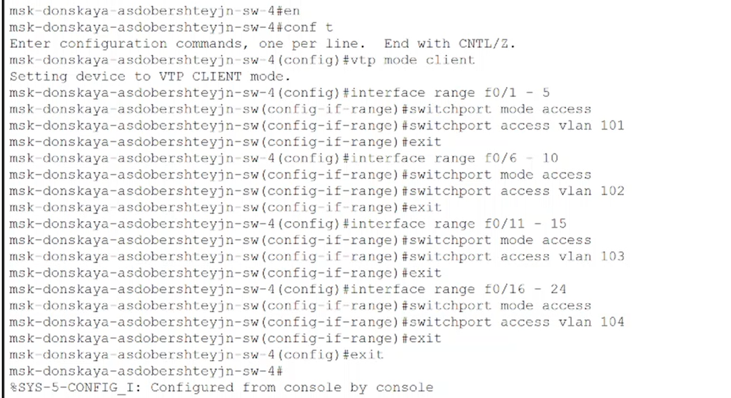

Настройка коммутатора msk-donskaya-asdobershteyjn-sw-4 как VTP-клиент

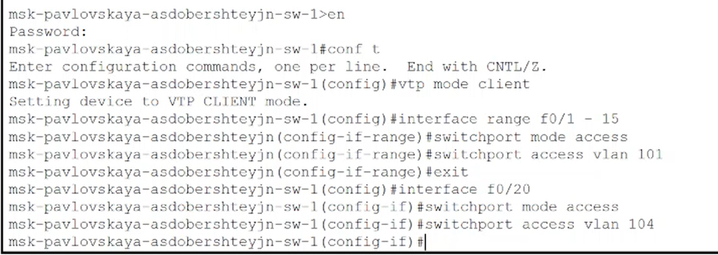

Настройка коммутатора msk-pavlovskaya-asdobershteyjn-sw-1 как VTP-клиент

Указала статические IP-адреса на оконечных устройствах и серверах. (рис. @fig:011).

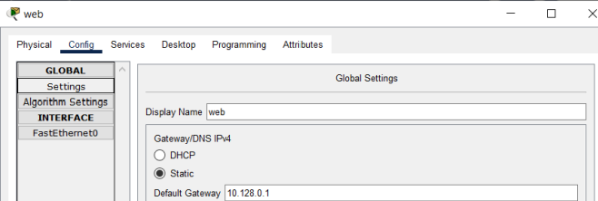

Указание шлюза для серверов

[figure not shown]

Указание ip-адреса для сервера web

[figure not shown]

Указание ip-адреса для сервера file

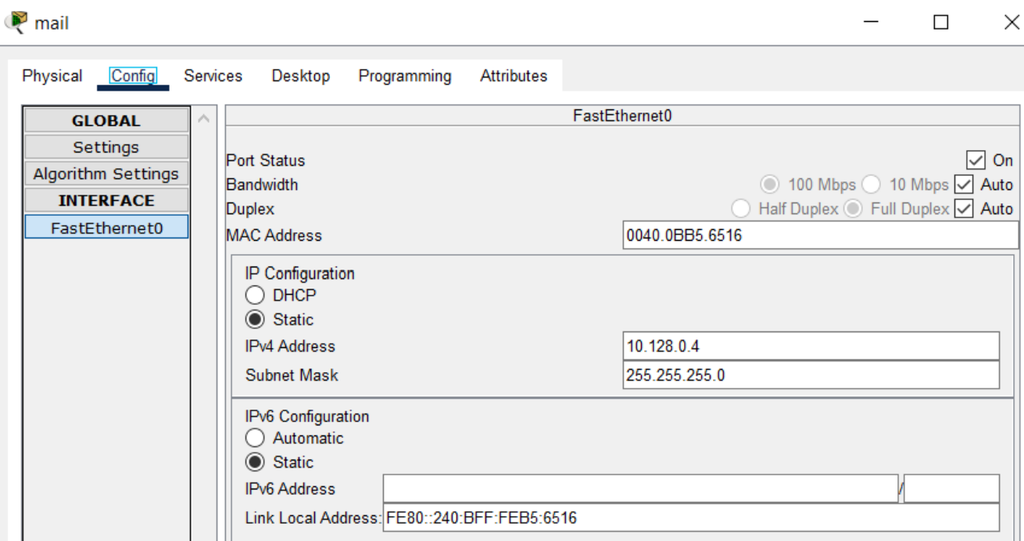

Указание ip-адреса для сервера mail

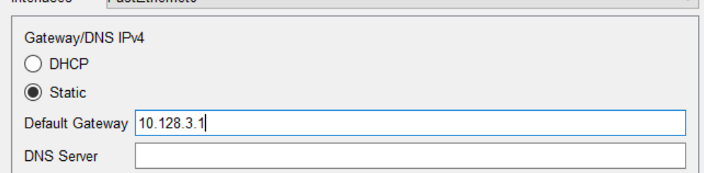

Указание шлюза для ДК (Донская)

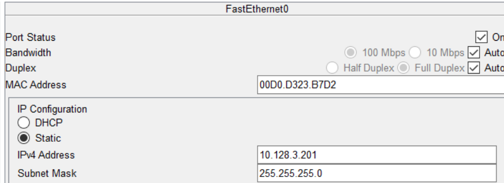

Указание ip-адреса для ДК (Донская)

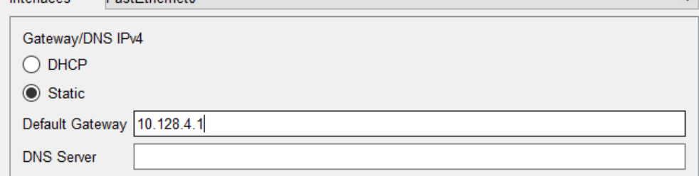

Указание шлюза для Кафедр

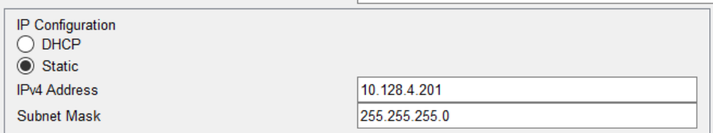

Указание ip-адреса для Кафедр

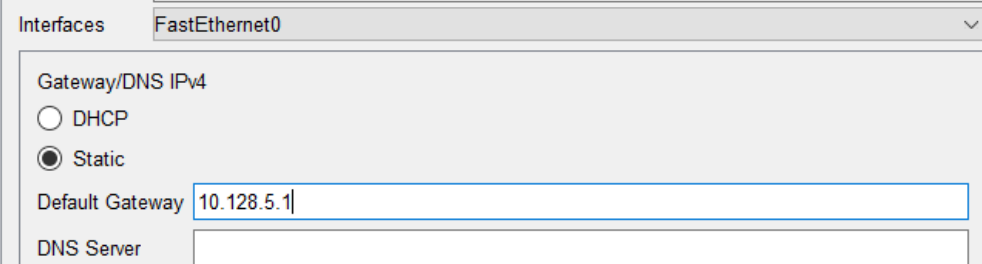

Указание шлюза для Администрации

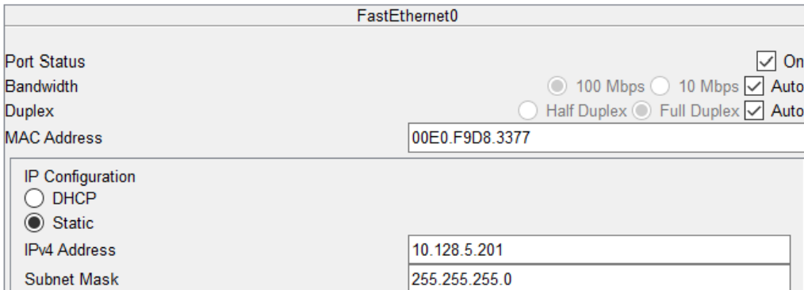

Указание ip-адреса для Администрации

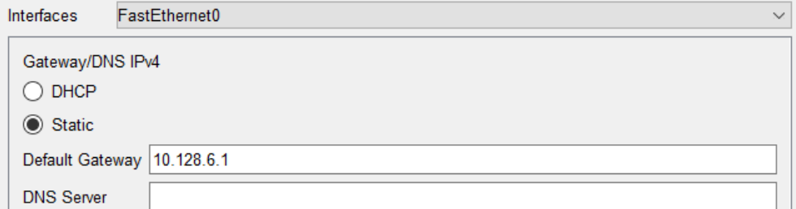

Указание шлюза для Других пользователей (Донская)

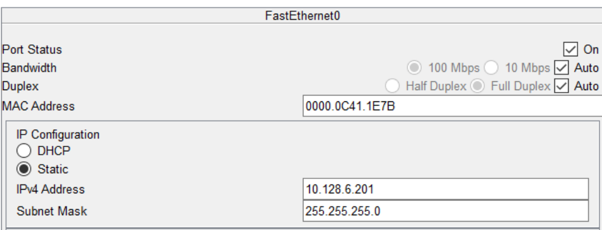

Указание ip-адреса для Других пользователей (Донская)

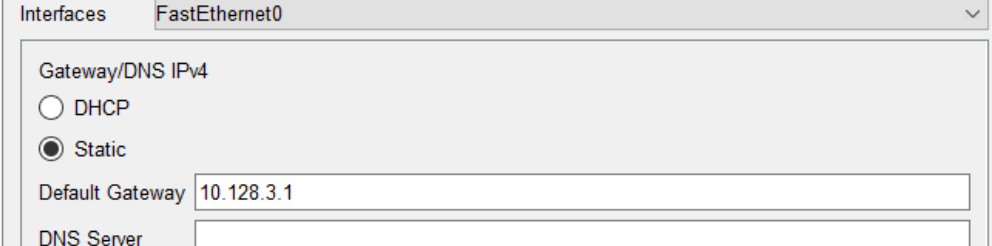

Указание шлюза для ДК (Павловская)

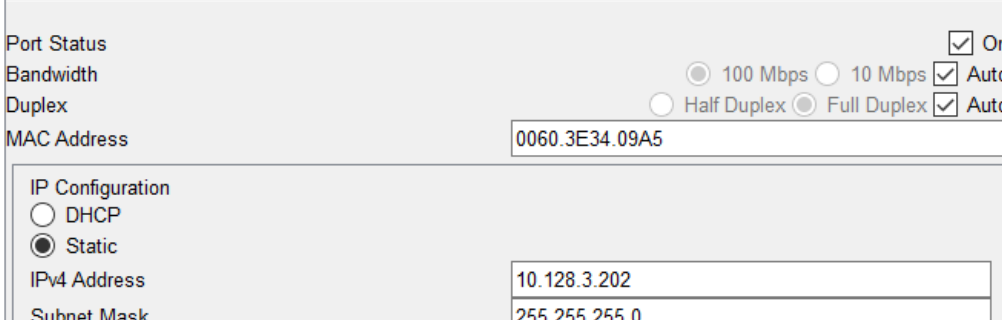

Указание ip-адреса для ДК (Павловская)

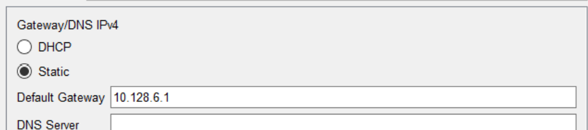

Указание шлюза для Других пользователей (Павловская)

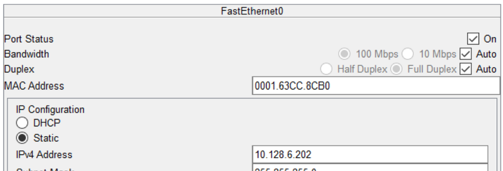

Указание ip-адреса для Других пользователей (Павловская)

Проверила с помощью команды ping доступность устройств, принадлежащих к одному VLAN и недоступность устройств, принадлежащих разным VLAN.(рис. @fig:027).

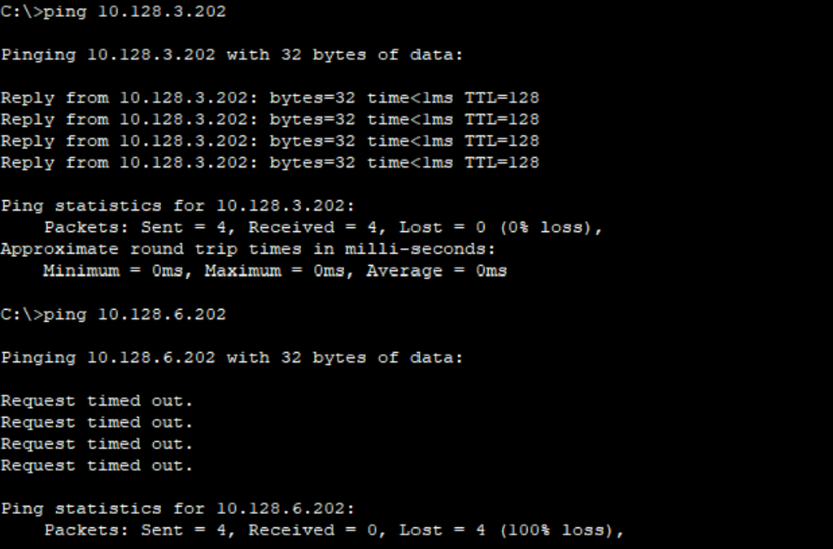

ping

Используя режим симуляции, изучила процесс передвижения пакета ICMP по сети. Должна была, но у меня этого пакета не было, к сожалению.

# Выводы

Я получила основные навыки по настройке VLAN на коммутаторах сети.